# What Affect White Wine Quality by Francis Tam

### More on Quality, Density & Alcohol

Let’s take a deeper look in alcohol, density and quality, as they showed some trends in the box plots and scatter plots above.

First, let’s make density the x-axis and quality the y-axis.

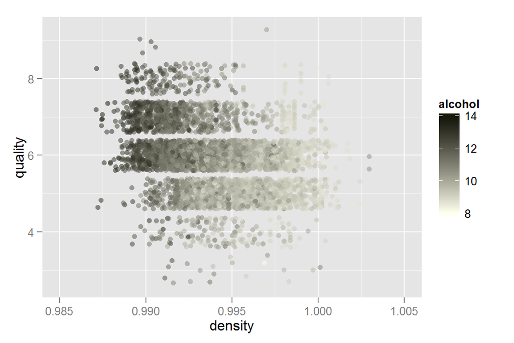

```r
ggplot(aes(density, quality, color=alcohol), data=ww) +
  geom_point(alpha = 1/2, size = 2, position = 'jitter') +
  scale_x_continuous(limits = c(0.985, 1.005)) +
  scale_color_gradient(high='#111100', low='#ffffee')
```

Not a very sharp indicator but the “high” region does look darker meaning higher alcohol content might contribute to a better white wine.

Let’s do the other way round by coloring on density too.

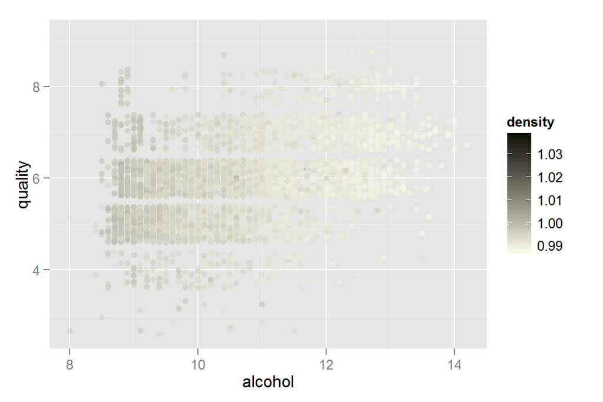

```r
ggplot(aes(alcohol, quality, color=density), data=ww) +
  geom_point(alpha = 1/2, size = 2, position = 'jitter') +
  scale_color_gradient(high='#111100', low='#ffffee')
```

Not very indicative though.

Finally let’s put alcohol in the x-axis and density in the y-axis.

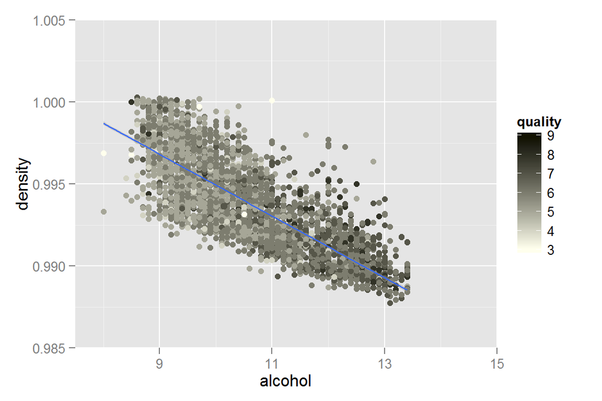

```r
ggplot(aes(alcohol, density), data=ww) +
  geom_point(aes(color=quality)) +
  coord_cartesian(xlim=c(7.5,15), ylim=c(0.985, 1.005)) +
  scale_x_continuous(limits=c(0, quantile(ww$alcohol, 0.99))) +
  scale_y_continuous(limits=c(0, quantile(ww$density, 0.99))) +
  scale_color_gradient(high='#111100', low='#ffffee') +
  stat_smooth(method="lm")
```

```r
cor.test(ww$alcohol,ww$density)
```

```
##
##  Pearson's product-moment correlation
##
## data:  ww$alcohol and ww$density
## t = -87.255, df = 4896, p-value < 2.2e-16
## alternative hypothesis: true correlation is not equal to 0
## 95 percent confidence interval:
##  -0.7908646 -0.7689315
## sample estimates:
##        cor
## -0.7801376
```

As stated above, alcohol and density are negatively correlated (r = -0.78). The above plot also seems to suggest that alcohol is correlated to quality too. It also appears that the better quality white wines are more concentrated on the high alcohol but low density quadrant. More on the later section.

# Multivariate Analysis

### Were there any interesting or surprising interactions between features?

Surprisingly, the chemicals likes chlorides, sulphates, acids, etc. do not as much contribute to the perceived quality of white wine. Considering density is actually increased by sugar content but decreased by alcohol content, alcohol in fact contributes the most to the quality of a white wine!

Of course it doesn’t mean that alcohol only will make a good wine. This analysis just indicates that within the samples tested, which assemble a lot of the white wines in the market, alcohol is the main contributor to perceived quality. The other chemicals, including alcohol itself, need to be in reasonable ranges to be classified as white wine.

### OPTIONAL: Did you create any models with your dataset? Discuss the strengths and limitations of your model.

```r
wwm1 <- lm(I(quality) ~ I(alcohol), data=ww)
wwm2 <- update(wwm1, ~ . + density)
mtable(wwm1,wwm2)
```

```
##
## Calls:
## wwm1: lm(formula = I(quality) ~ I(alcohol), data = ww)
## wwm2: lm(formula = I(quality) ~ I(alcohol) + density, data = ww)
##
## =====================================
##                    wwm1       wwm2
## -------------------------------------
## (Intercept)      2.582***  -22.492***
##                 (0.098)     (6.165)
## I(alcohol)       0.313***    0.360***
##                 (0.009)     (0.015)
## density                     24.728***
##                             (6.079)
## -------------------------------------
## R-squared           0.190      0.192
## adj. R-squared      0.190      0.192
## sigma               0.797      0.796
## F                1146.395    583.290
## p                   0.000      0.000
## Log-likelihood  -5839.391  -5831.127
## Deviance         3112.257   3101.773
## AIC             11684.782  11670.255
## BIC             11704.272  11696.241
## N                4898       4898
## =====================================
```

Even we try to develop a model with the best correlated vectors to predict quality, the R-squared is really too low. It might indicate that we might have missed some important variables in the dataset which can better predict quality.

Or, there is possibility that the quality scale has too precise levels. It is natural that predictions work better if we make it less levels, say just good, average, and bad.

# Final Plots and Summary

### Plot One

All wines are labeled with alcohol % in volume so it must be an important factor for consumers to choose, but recently some sweet wines emerge in the market. So what about sweetness? Is it gaining importance? Let’s see in the below graph:

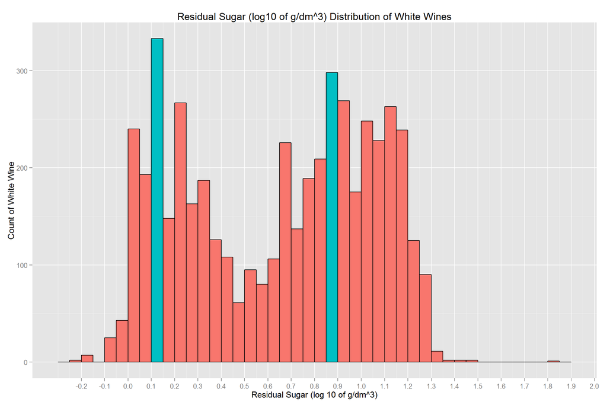

```r
ww$residual.sugar.f <- as.factor((log10(ww$residual.sugar)>0.1 &
                                   log10(ww$residual.sugar)<=0.15) |
                                   (log10(ww$residual.sugar)>0.85 &
                                      log10(ww$residual.sugar)<=0.9 ))
ggplot(aes(log10(residual.sugar), fill=residual.sugar.f), data=ww) +
  geom_histogram(binwidth=0.05, color='black') +
  scale_x_continuous(breaks=seq(-0.2, 2, 0.1)) +
  xlab("Residual Sugar (log 10 of g/dm^3)") +
  ylab("Count of White Wine") +
  ggtitle('Residual Sugar (log10 of g/dm^3) Distribution of White Wines') +
  theme(legend.position="none")
```

### Description One

So the interesting finding is that the distribution of residual sugar (log 10) in white wines appears to be bi-modal and the modes happen at 0.1 & 0.9 (log10 of g/dm^3). It might indicate that the demand of white wines come in two ranges of sweetness levels. Some prefer less sweet, some prefer more, although sweeter or not does not necessarily make a good white wine!!

### Plot Two

And as discussed above, alcohol seems to be an important factor for people to choose white wine. Is it so? Let’s see in the following box plot:

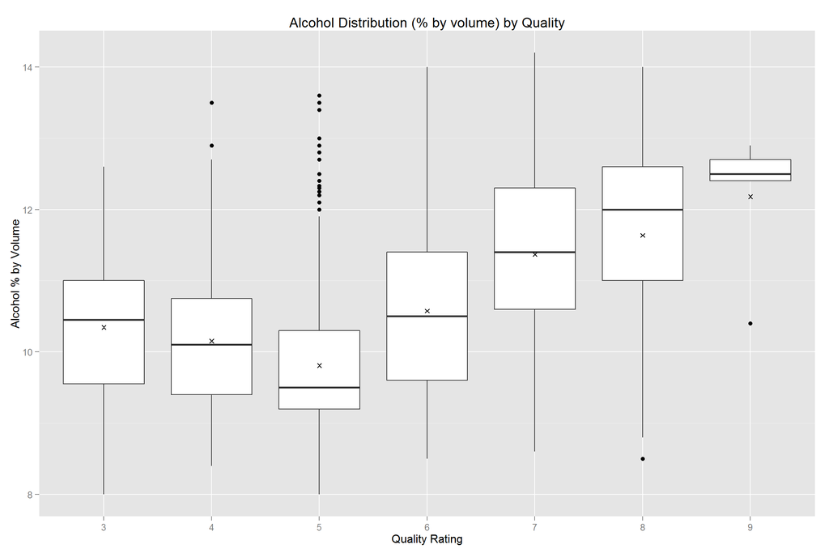

```r
ggplot(aes(quality.f, alcohol), data=ww) +
  geom_boxplot() +
  stat_summary(fun.y = mean, geom='point', shape=4) +
  xlab("Quality Rating") +
  ylab("Alcohol % by Volume") +
  ggtitle('Alcohol Distribution (% by volume) by Quality') +
  theme(legend.position="none")
```

### Description Two

It can be noticed that after quality rating 5, quality improves in general as alcohol % increases. E.g. at rating 5, the median alcohol % is around 9.5%. When quality gets higher, the alcohol % moves up eventually to around 12.5%.

All in all, it indicates that people drinks white wine for its alcohol content insides, and the more, the better!

Additional Information: But the number of data point gets really thin at two ends so statistically, we have less confidence there:

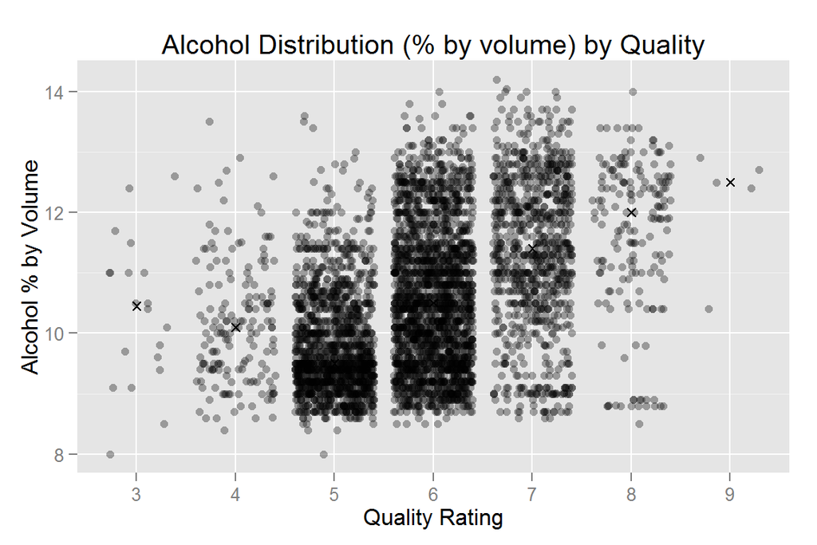

```r
ggplot(aes(quality.f, alcohol), data=ww) +
  geom_jitter(alpha=1/3, size=2) +
  stat_summary(fun.y = median, geom='point', shape=4) +
  xlab("Quality Rating") +
  ylab("Alcohol % by Volume") +
  ggtitle('Alcohol Distribution (% by volume) by Quality') +
  theme(legend.position="none")
```

### Plot Three

Finally, people talk about texture and density when choosing a white wine. Is that important too? Let’s see density, alcohol and quality in one graph.

Because the gradient scale is not sharp enough above and we want to reveal both the good and bad wines, let’s use different color scheme for them:

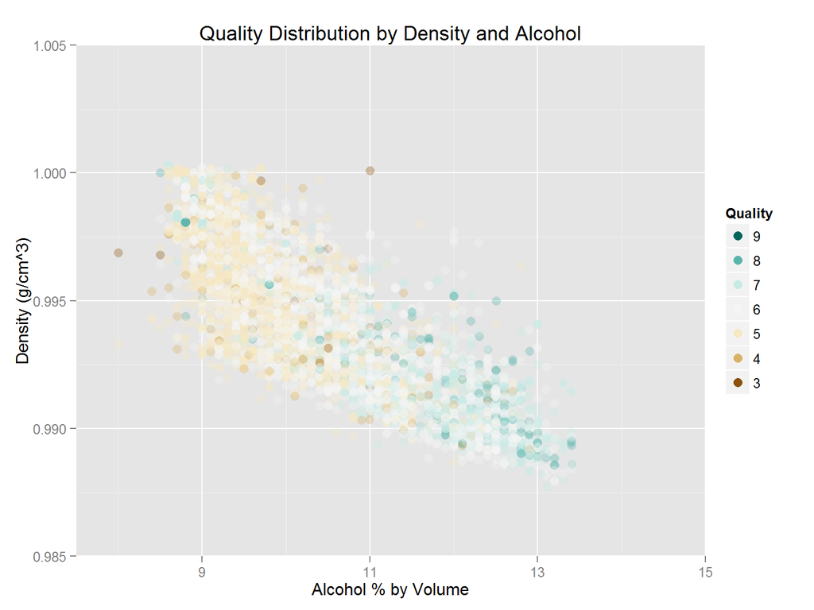

```r
ggplot(aes(alcohol, density, color=quality.f), data=ww) +
  geom_point(alpha = 1/3, size = 3, position = 'jitter') +
  coord_cartesian(xlim=c(7.5,15), ylim=c(0.985, 1.005)) +
  scale_x_continuous(limits=c(0, quantile(ww$alcohol, 0.99))) +
  scale_y_continuous(limits=c(0, quantile(ww$density, 0.99))) +
  scale_color_brewer(type='div',
    guide = guide_legend(title = 'Quality', reverse = T,
      override.aes = list(alpha = 1, size = 3))) +
  xlab("Alcohol % by Volume") +
  ylab("Density (g/cm^3)") +
  ggtitle('Quality Distribution by Density and Alcohol')
```

It seems the green dots, indicating a good white wine, are concentrated in the lower right quardrant but the brown dots, indicating a bad white wine, are concentrated in the upper left quardrant.

### Description Three

It can be noticed that the better quality white wines are more concentrated at the quadrant with higher alcohol % but lower density. E.g. the better quality white wines are concentrated around 0.990 density and 13% alcohol. In contrast the worse quality white wines are at the lower alcohol % but higher density, like those with 0.998 density and 9% alcohol. It might suggest that people perceive a white wine better when the alcohol content goes up, and the density goes down.

Actually, density is increased by the sugar content but decreased by the alcohol content. In the brewing process, sugar is consumed to produce alcohol. So this might indicate that if the wine is brewed longer, the quality is better. Although the graph might show that quality simply depends on density and alcohol, but maybe it suggests implicitly the duration of brewing is also important, which is not provided in this dataset.

# Reflection

As we found out, alcohol, among the other chemicals/attributes in the dataset, seems to contribute the most to the quality. That might explain why if the wines are brewed longer, more sugar is transformed to alcohol thus making a better wine. However, it is still a poor prediction model after all. We might have missed some more important attributes.

Despite EDA is a great tool to help us find the possible correlated variables in a dataset, it is not a guarantee to find a good prediction model (not to mention the variables can have other problems like autocorrelation).

There were some struggles during the analysis. Despite there are many variables provided in the dataset, initially there are no relationships revealed among them and the most interested one, quality. We had to exploit every variable and exhausted all the charts before starting spotting something - the GGally package is a great tool because it lets you plot all the bivariate plots in one go and immediately identify all the correlations. Once we noted there is a trend in alcohol and density, we summarized these 2 variables and quality in one chart and a relationship is finally revealed among them.

Actually in this dataset, we are very focused on only limited number of chemicals in the wine. In fact there are many more: considering the balance of the wine, apart from sweetness, acidity and alcohol, tannin is another important chemical. Other attributes like “aftertaste”, “complexity”, “depth”, might be becasue of more than 20 minerals, phytochemicals, and even proteins too (http://en.wikipedia.org/wiki/Wine_chemistry). Sulfur oxides, sulphates, citric acid are really preservatives which might not contribute as much aroma or taste to the wine itself, hence quality. In short, we need more variables in future analysis to determine a better prediction model.

On other other hand, it will be interesting to include price, brand and year in the dataset too. It is widely known that year, vineyard, locations and countries might contribute to quality, and thus price too. It will be very interesting to find out if there are indeed correlations among these factors!